# Data605 Final Project

Henry Otuadinma

12/12/2019

### Problem 1.

#### Using R, generate a random variable X that has 10,000 random uniform numbers from 1 to N, where N can be any number of your choosing greater than or equal to 6. Then generate a random variable Y that has 10,000 random normal numbers with a mean of $\mu = \sigma = \frac{(N+1)}{2}$

```r
set.seed(12345)
```

```r
N <- 10
n <- 10000
mn <- sigma <- (N + 1)/2
```

```r
df <- data.frame(X = runif(n, min = 1, max = N), Y = rnorm(n, mean = mn, sd = sigma))

head(df)
```

```
##          X         Y
## 1 7.488135  1.691403
## 2 8.881959 11.685826
## 3 7.848841  6.459943
## 4 8.975121 -5.322937
## 5 5.108329 -3.543494
## 6 2.497346  4.896184
```

```r
kable(head(df)) %>% kable_styling(bootstrap_options = "striped", full_width = T, position = "left")
```

| X | Y |
| --- | --- |
| 7.488135 | 1.691403 |
| 8.881959 | 11.685826 |
| 7.848841 | 6.459943 |
| 8.975121 | -5.322937 |
| 5.108329 | -3.543494 |
| 2.497346 | 4.896184 |

```r
kable(summary(df)) %>% kable_styling(bootstrap_options = "striped", full_width = T, position = "left")
```

|  | X | Y |
| --- | --- | --- |
|  | Min. : 1.000 | Min. :-14.664 |
|  | 1st Qu.: 3.283 | 1st Qu.: 1.846 |
|  | Median : 5.541 | Median : 5.482 |
|  | Mean : 5.506 | Mean : 5.500 |
|  | 3rd Qu.: 7.742 | 3rd Qu.: 9.154 |
|  | Max. :10.000 | Max. : 26.766 |

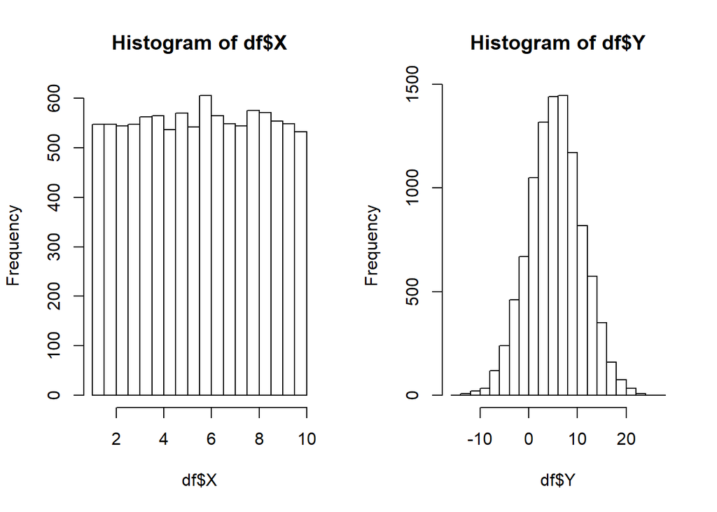

```r
par(mfrow=c(1, 2))
hist(df$X)
hist(df$Y)
```

#### Probability.

##### Calculate as a minimum the below probabilities a through c. Assume the small letter “x” is estimated as the median of the X variable, and the small letter “y” is estimated as the 1st quartile of the Y variable. Interpret the meaning of all probabilities.

First finding the quartiles:

```r
(x = quantile(df$X, 0.5))
```

```
##      50%
## 5.540952
```

```r
(y = quantile(df$Y, 0.25))
```

```
##      25%
## 1.846076
```

##### a. P(X>x | X>y)

Assuming X = A and B = Y, then the probability of A occurring if B has occurred is denoted by P(A|B). Using the dataframe ‘df’ from the first step above =>

```r
pbx_of_x <- df %>% filter(X > x, X > y) %>% nrow()/n
```

```r
pb_of_x <- df %>% filter(X > y) %>% nrow()/n
```

```r
(Qnt_x = pbx_of_x/pb_of_x)
```

```
## [1] 0.5512679
```

Therefore, the probability of A = 5.54 is greater than B = 1.85 is 0.55.

2. P(X>x, Y>y)

```r
(Qnt_b = df %>% filter(X > x, Y > y) %>% nrow()/n)
```

```
## [1] 0.3808
```

This means that the probablity of A (5.54) being greater than B (1.85) is 0.38.

3. P(X<x | X>y)

```r
pbx_of_x = df %>% filter(X < x, X > y) %>% nrow()/n

pb_of_x = df %>% filter(X > y) %>% nrow()/n

(Qnt_x = pbx_of_x/pb_of_x)
```

```
## [1] 0.4487321
```

#### Investigate whether P(X>x and Y>y) = P(X>x)P(Y>y) by building a table and evaluating the marginal and joint probabilities.

```r
r<-ifelse(df$X>x,"X>x","X<x")
q <- ifelse(df$Y> y , 'Y>y', 'Y<y')


tbl <- table(r,q)
```

```r
kable(addmargins(head(tbl)), table.attr = "style = \"color: #000;\"") %>% kable_styling(bootstrap_options = "striped", full_width = T, position = "left")
```

|  | Y<y | Y>y | Sum |
| --- | --- | --- | --- |
| X<x | 1308 | 3692 | 5000 |
| X>x | 1192 | 3808 | 5000 |
| Sum | 2500 | 7500 | 10000 |

```r
kable(addmargins(prop.table(table(r,q))), table.attr = "style = \"color: #000;\"") %>% kable_styling(bootstrap_options = c("bordered", 'striped'))
```

|  | Y<y | Y>y | Sum |
| --- | --- | --- | --- |
| X<x | 0.1308 | 0.3692 | 0.5 |
| X>x | 0.1192 | 0.3808 | 0.5 |
| Sum | 0.2500 | 0.7500 | 1.0 |

```r
yf <-ifelse(df$X>x & df$Y>y,"X>x &Y>y","not")
```

```r
kable((prop.table(table(yf))), table.attr = "style = \"color: #000;\"") %>% kable_styling(bootstrap_options = "bordered")
```

| yf | Freq |
| --- | --- |
| not | 0.6192 |
| X>x &Y>y | 0.3808 |

#### Check to see if independence holds by using Fisher’s Exact Test and the Chi Square Test. What is the difference between the two? Which is most appropriate?

```r
chisq.test(tbl, correct =  T)
```

```
##
##  Pearson's Chi-squared test with Yates' continuity correction
##
## data:  tbl
## X-squared = 7.0533, df = 1, p-value = 0.007912
```

```r
fisher.test(tbl, simulate.p.value = T)
```

```
##
##  Fisher's Exact Test for Count Data
##
## data:  tbl
## p-value = 0.007904
## alternative hypothesis: true odds ratio is not equal to 1
## 95 percent confidence interval:
##  1.032680 1.240419
## sample estimates:
## odds ratio
##   1.131777
```

##### The chisq test is for large sample sizes, while fisher’s exact test is for relatively small sample sizes. Therefore, the Chi Square test is most appropriate for this case.

### Problem 2

##### You are to register for Kaggle.com (free) and compete in the House Prices: Advanced Regression Techniques competition. https://www.kaggle.com/c/house-prices-advanced-regression-techniques . I want you to do the following.

### Descriptive and Inferential Statistics:

#### Provide univariate descriptive statistics and appropriate plots for the training data set.

```r
trainData <- read.csv2('https://raw.githubusercontent.com/henryvalentine/MSDS2019/master/Classes/605/Final%20Project/train.csv',stringsAsFactors = TRUE,header = T, sep = ',', na.strings = 'NA')
testData <- read.csv2('https://raw.githubusercontent.com/henryvalentine/MSDS2019/master/Classes/605/Final%20Project/test.csv',stringsAsFactors = TRUE,header = T, sep = ',', na.strings = 'NA')
```

Preview Train data

```r
datatable(head(trainData), class = 'cell-border stripe', options = list(
  initComplete = JS(
    "function(settings, json) {",
    "$(this.api().table().header()).css({'background-color': '#337ab7', 'color': '#fff', 'text-align': 'center !important'});",
    "$(this.api().table().body()).css({'color': '#000', 'text-align': 'center !important'});",
    "}")
))
```

|  | Id | MSSubClass | MSZoning | LotFrontage | LotArea | Street | Alley | LotShape | LandContour | Utilities | LotConfig | LandSlope | Neighborhood | Condition1 | Condition2 | BldgType | HouseStyle | OverallQual | OverallCond | YearBuilt | YearRemodAdd | RoofStyle | RoofMatl | Exterior1st | Exterior2nd | MasVnrType | MasVnrArea | ExterQual | ExterCond | … |
| --- | --- | --- | --- | --- | --- | --- | --- | --- | --- | --- | --- | --- | --- | --- | --- | --- | --- | --- | --- | --- | --- | --- | --- | --- | --- | --- | --- | --- | --- | --- |
| 1 | 1 | 60 | RL | 65 | 8450 | Pave |  | Reg | Lvl | AllPub | Inside | Gtl | CollgCr | Norm | Norm | 1Fam | 2Story | 7 | 5 | 2003 | 2003 | Gable | CompShg | VinylSd | VinylSd | BrkFace | 196 | Gd | TA | … |
| 2 | 2 | 20 | RL | 80 | 9600 | Pave |  | Reg | Lvl | AllPub | FR2 | Gtl | Veenker | Feedr | Norm | 1Fam | 1Story | 6 | 8 | 1976 | 1976 | Gable | CompShg | MetalSd | MetalSd | None | 0 | TA | TA | … |
| 3 | 3 | 60 | RL | 68 | 11250 | Pave |  | IR1 | Lvl | AllPub | Inside | Gtl | CollgCr | Norm | Norm | 1Fam | 2Story | 7 | 5 | 2001 | 2002 | Gable | CompShg | VinylSd | VinylSd | BrkFace | 162 | Gd | TA | … |
| 4 | 4 | 70 | RL | 60 | 9550 | Pave |  | IR1 | Lvl | AllPub | Corner | Gtl | Crawfor | Norm | Norm | 1Fam | 2Story | 7 | 5 | 1915 | 1970 | Gable | CompShg | Wd Sdng | Wd Shng | None | 0 | TA | TA | … |
| 5 | 5 | 60 | RL | 84 | 14260 | Pave |  | IR1 | Lvl | AllPub | FR2 | Gtl | NoRidge | Norm | Norm | 1Fam | 2Story | 8 | 5 | 2000 | 2000 | Gable | CompShg | VinylSd | VinylSd | BrkFace | 350 | Gd | TA | … |
| 6 | 6 | 50 | RL | 85 | 14115 | Pave |  | IR1 | Lvl | AllPub | Inside | Gtl | Mitchel | Norm | Norm | 1Fam | 1.5Fin | 5 | 5 | 1993 | 1995 | Gable | CompShg | VinylSd | VinylSd | None | 0 | TA | TA | … |

Preview Test data

```r
datatable(head(testData), class = 'cell-border stripe', options = list(
  initComplete = JS(
    "function(settings, json) {",
    "$(this.api().table().header()).css({'background-color': '#337ab7', 'color': '#fff', 'text-align': 'center !important'});",
    "$(this.api().table().body()).css({'color': '#000', 'text-align': 'center !important'});",
    "}")
))
```

|  | Id | MSSubClass | MSZoning | LotFrontage | LotArea | Street | Alley | LotShape | LandContour | Utilities | LotConfig | LandSlope | Neighborhood | Condition1 | Condition2 | BldgType | HouseStyle | OverallQual | OverallCond | YearBuilt | YearRemodAdd | RoofStyle | RoofMatl | Exterior1st | Exterior2nd | MasVnrType | MasVnrArea | ExterQual | ExterCond | … |
| --- | --- | --- | --- | --- | --- | --- | --- | --- | --- | --- | --- | --- | --- | --- | --- | --- | --- | --- | --- | --- | --- | --- | --- | --- | --- | --- | --- | --- | --- | --- |
| 1 | 1461 | 20 | RH | 80 | 11622 | Pave |  | Reg | Lvl | AllPub | Inside | Gtl | NAmes | Feedr | Norm | 1Fam | 1Story | 5 | 6 | 1961 | 1961 | Gable | CompShg | VinylSd | VinylSd | None | 0 | TA | TA | … |
| 2 | 1462 | 20 | RL | 81 | 14267 | Pave |  | IR1 | Lvl | AllPub | Corner | Gtl | NAmes | Norm | Norm | 1Fam | 1Story | 6 | 6 | 1958 | 1958 | Hip | CompShg | Wd Sdng | Wd Sdng | BrkFace | 108 | TA | TA | … |
| 3 | 1463 | 60 | RL | 74 | 13830 | Pave |  | IR1 | Lvl | AllPub | Inside | Gtl | Gilbert | Norm | Norm | 1Fam | 2Story | 5 | 5 | 1997 | 1998 | Gable | CompShg | VinylSd | VinylSd | None | 0 | TA | TA | … |
| 4 | 1464 | 60 | RL | 78 | 9978 | Pave |  | IR1 | Lvl | AllPub | Inside | Gtl | Gilbert | Norm | Norm | 1Fam | 2Story | 6 | 6 | 1998 | 1998 | Gable | CompShg | VinylSd | VinylSd | BrkFace | 20 | TA | TA | … |
| 5 | 1465 | 120 | RL | 43 | 5005 | Pave |  | IR1 | HLS | AllPub | Inside | Gtl | StoneBr | Norm | Norm | TwnhsE | 1Story | 8 | 5 | 1992 | 1992 | Gable | CompShg | HdBoard | HdBoard | None | 0 | Gd | TA | … |
| 6 | 1466 | 60 | RL | 75 | 10000 | Pave |  | IR1 | Lvl | AllPub | Corner | Gtl | Gilbert | Norm | Norm | 1Fam | 2Story | 6 | 5 | 1993 | 1994 | Gable | CompShg | HdBoard | HdBoard | None | 0 | TA | TA | … |

##### selecting only numeric variables from the training dataframe:

```r
trn_numeric <- trainData[,sapply(trainData, is.numeric)][-1]
```

```r
describe(trn_numeric)
```

```
## trn_numeric
##
##  37  Variables      1460  Observations
## ---------------------------------------------------------------------------
## MSSubClass
##        n  missing distinct     Info     Mean      Gmd      .05      .10
##     1460        0       15     0.94     56.9    43.19       20       20
##      .25      .50      .75      .90      .95
##       20       50       70      120      160
##
## lowest :  20  30  40  45  50, highest:  90 120 160 180 190
##
## Value         20    30    40    45    50    60    70    75    80    85
## Frequency    536    69     4    12   144   299    60    16    58    20
## Proportion 0.367 0.047 0.003 0.008 0.099 0.205 0.041 0.011 0.040 0.014
##
## Value         90   120   160   180   190
## Frequency     52    87    63    10    30
## Proportion 0.036 0.060 0.043 0.007 0.021
## ---------------------------------------------------------------------------
## LotFrontage
##        n  missing distinct     Info     Mean      Gmd      .05      .10
##     1201      259      110    0.998    70.05    24.61       34       44
##      .25      .50      .75      .90      .95
##       59       69       80       96      107
##
## lowest :  21  24  30  32  33, highest: 160 168 174 182 313
## ---------------------------------------------------------------------------
## LotArea
##        n  missing distinct     Info     Mean      Gmd      .05      .10
##     1460        0     1073        1    10517     5718     3312     5000
##      .25      .50      .75      .90      .95
##     7554     9478    11602    14382    17401
##
## lowest :   1300   1477   1491   1526   1533, highest:  70761 115149 159000 164660 215245
## ---------------------------------------------------------------------------
## OverallQual
##        n  missing distinct     Info     Mean      Gmd      .05      .10
##     1460        0       10    0.951    6.099    1.522        4        5
##      .25      .50      .75      .90      .95
```

[output cut: 301 more lines]

```
##
## lowest : 2006 2007 2008 2009 2010, highest: 2006 2007 2008 2009 2010
##
## Value       2006  2007  2008  2009  2010
## Frequency    314   329   304   338   175
## Proportion 0.215 0.225 0.208 0.232 0.120
## ---------------------------------------------------------------------------
## SalePrice
##        n  missing distinct     Info     Mean      Gmd      .05      .10
##     1460        0      663        1   180921    81086    88000   106475
##      .25      .50      .75      .90      .95
##   129975   163000   214000   278000   326100
##
## lowest :  34900  35311  37900  39300  40000, highest: 582933 611657 625000 745000 755000
## ---------------------------------------------------------------------------
```

```r
str(trn_numeric)
```

```
## 'data.frame':    1460 obs. of  37 variables:
##  $ MSSubClass   : int  60 20 60 70 60 50 20 60 50 190 ...
##  $ LotFrontage  : int  65 80 68 60 84 85 75 NA 51 50 ...
##  $ LotArea      : int  8450 9600 11250 9550 14260 14115 10084 10382 6120 7420 ...
##  $ OverallQual  : int  7 6 7 7 8 5 8 7 7 5 ...
##  $ OverallCond  : int  5 8 5 5 5 5 5 6 5 6 ...
##  $ YearBuilt    : int  2003 1976 2001 1915 2000 1993 2004 1973 1931 1939 ...
##  $ YearRemodAdd : int  2003 1976 2002 1970 2000 1995 2005 1973 1950 1950 ...
##  $ MasVnrArea   : int  196 0 162 0 350 0 186 240 0 0 ...
##  $ BsmtFinSF1   : int  706 978 486 216 655 732 1369 859 0 851 ...
##  $ BsmtFinSF2   : int  0 0 0 0 0 0 0 32 0 0 ...
##  $ BsmtUnfSF    : int  150 284 434 540 490 64 317 216 952 140 ...
##  $ TotalBsmtSF  : int  856 1262 920 756 1145 796 1686 1107 952 991 ...
##  $ X1stFlrSF    : int  856 1262 920 961 1145 796 1694 1107 1022 1077 ...
##  $ X2ndFlrSF    : int  854 0 866 756 1053 566 0 983 752 0 ...
```

[output cut: 23 more lines]

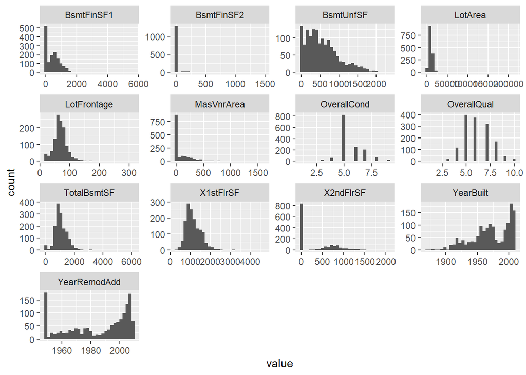

```r
trn_numeric[, 2:14] %>% tidyr::gather() %>%ggplot(aes(value)) + facet_wrap(~ key, scales = "free") + geom_histogram()
```

Further removing variables with large amount of zeros:

```r
df <- trn_numeric[,-c(6,11,16:19)]
```

```r
str(df)
```

```
## 'data.frame':    1460 obs. of  31 variables:
##  $ MSSubClass   : int  60 20 60 70 60 50 20 60 50 190 ...
##  $ LotFrontage  : int  65 80 68 60 84 85 75 NA 51 50 ...
##  $ LotArea      : int  8450 9600 11250 9550 14260 14115 10084 10382 6120 7420 ...
##  $ OverallQual  : int  7 6 7 7 8 5 8 7 7 5 ...
##  $ OverallCond  : int  5 8 5 5 5 5 5 6 5 6 ...
##  $ YearRemodAdd : int  2003 1976 2002 1970 2000 1995 2005 1973 1950 1950 ...
##  $ MasVnrArea   : int  196 0 162 0 350 0 186 240 0 0 ...
##  $ BsmtFinSF1   : int  706 978 486 216 655 732 1369 859 0 851 ...
##  $ BsmtFinSF2   : int  0 0 0 0 0 0 0 32 0 0 ...
##  $ TotalBsmtSF  : int  856 1262 920 756 1145 796 1686 1107 952 991 ...
##  $ X1stFlrSF    : int  856 1262 920 961 1145 796 1694 1107 1022 1077 ...
##  $ X2ndFlrSF    : int  854 0 866 756 1053 566 0 983 752 0 ...
##  $ LowQualFinSF : int  0 0 0 0 0 0 0 0 0 0 ...
##  $ HalfBath     : int  1 0 1 0 1 1 0 1 0 0 ...
```

[output cut: 17 more lines]

##### Histograms of ‘OverallQual’ and ‘OverallCond’

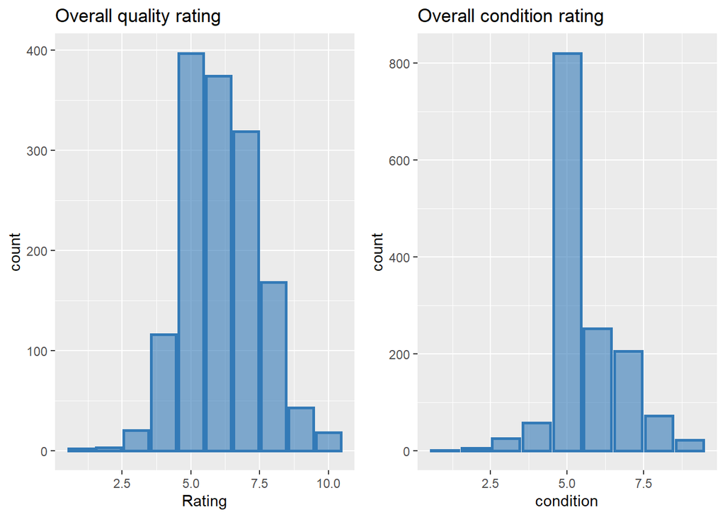

```r
qual = ggplot(trn_numeric, aes(trn_numeric$OverallQual)) + geom_bar(col = "#337ab7",
    fill = "#337ab7", alpha = 0.6, lwd = 1, na.rm = TRUE, position = "identity") +
    labs(title = "Overall quality rating") + labs(x = "Rating")

cond = ggplot(trn_numeric, aes(trn_numeric$OverallCond)) + geom_bar(col = "#337ab7",
    fill = "#337ab7", alpha = 0.6, lwd = 1, na.rm = TRUE, position = "identity") +
    labs(title = "Overall condition rating") + labs(x = "condition")

grid.arrange(qual, cond, nrow = 1)
```

##### Histograms of ‘GrLivArea’ and ‘LotArea’

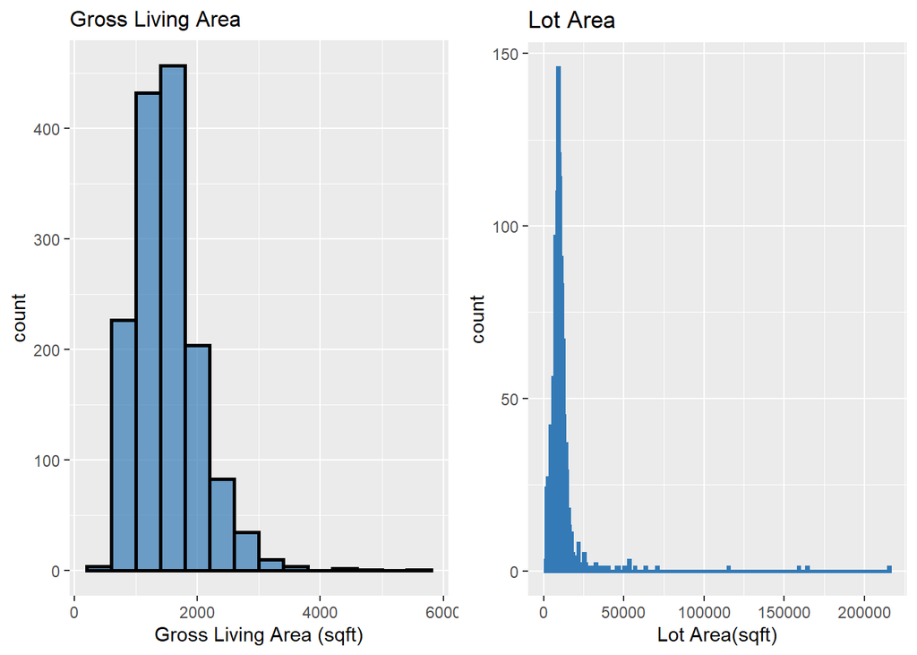

```r
grA = ggplot(trn_numeric, aes(trn_numeric$GrLivArea)) + geom_histogram(col = "black",
    binwidth = 400, fill = "#337ab7", alpha = 0.7, lwd = 1, na.rm = TRUE,
    position = "identity") + labs(title = "Gross Living Area") + labs(x = "Gross Living Area (sqft)") +
    theme(plot.title = element_text(size = 12))

lA = ggplot(trn_numeric, aes(trn_numeric$LotArea)) + geom_histogram(col = "#337ab7",
    binwidth = 600, fill = "#337ab7", alpha = 0.7, lwd = 1, na.rm = TRUE,
    position = "identity") + labs(title = "Lot Area") +
    labs(x = "Lot Area(sqft)")

grid.arrange(grA, lA, nrow = 1)
```

##### Histogram of Sale Price

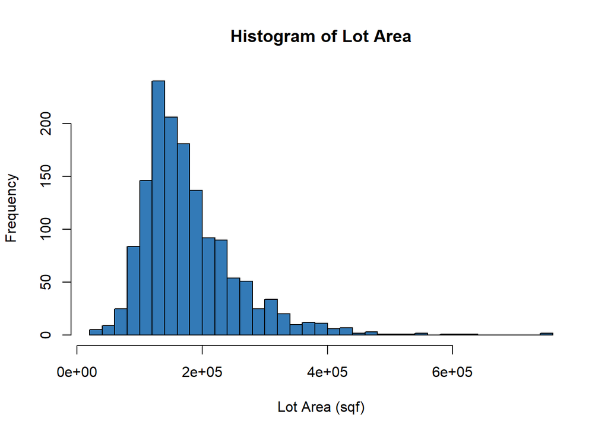

```r
sP = as.numeric(trn_numeric[,'SalePrice'])
hist(sP, breaks=35, main = "Histogram of Lot Area", xlab = 'Lot Area (sqf)', ylab = 'Frequency', col= '#337ab7')
```

#### Scatterplots

##### GrLivArea vs SalePrice

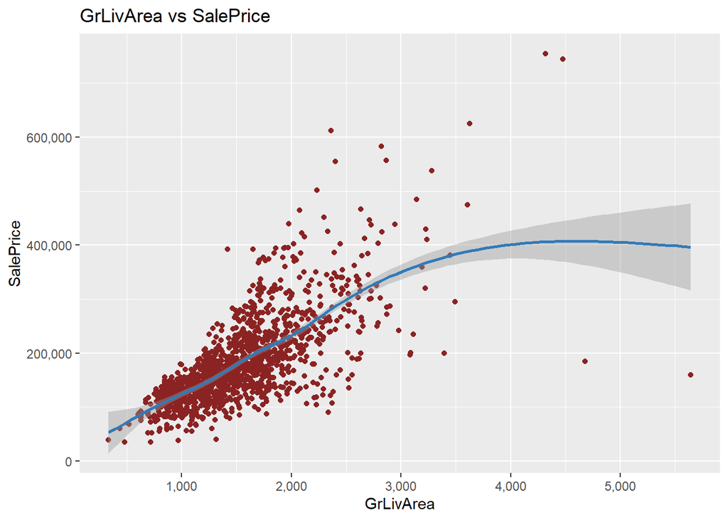

```r
ggplot(trn_numeric, aes(GrLivArea, SalePrice)) + geom_point(color = "brown4") + geom_smooth(method = "auto",
    col = "#337ab7") + ggtitle("GrLivArea vs SalePrice") +
    xlab("GrLivArea") + ylab("SalePrice") + scale_x_continuous(labels = comma) + scale_y_continuous(labels = comma)
```

##### There are some outliers in the above plot and these are caused by GrLvArea above 5, 000. Removing the outliers and re-ploting below:

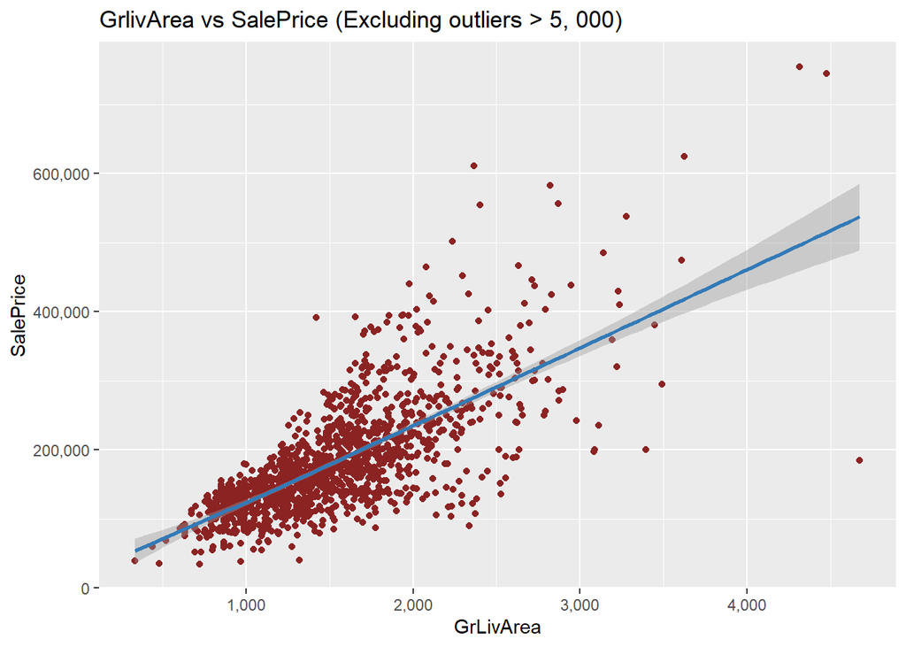

```r
trn_numeric %>% filter(GrLivArea < 5000) %>% ggplot(aes(GrLivArea, SalePrice)) + geom_point(color = "brown4") + geom_smooth(method = "auto",
    col = "#337ab7") + ggtitle("GrlivArea vs SalePrice (Excluding outliers > 5, 000)") +
    xlab("GrLivArea") + ylab("SalePrice") + scale_x_continuous(labels = comma) + scale_y_continuous(labels = comma)
```

###### LotArea vs SalePrice

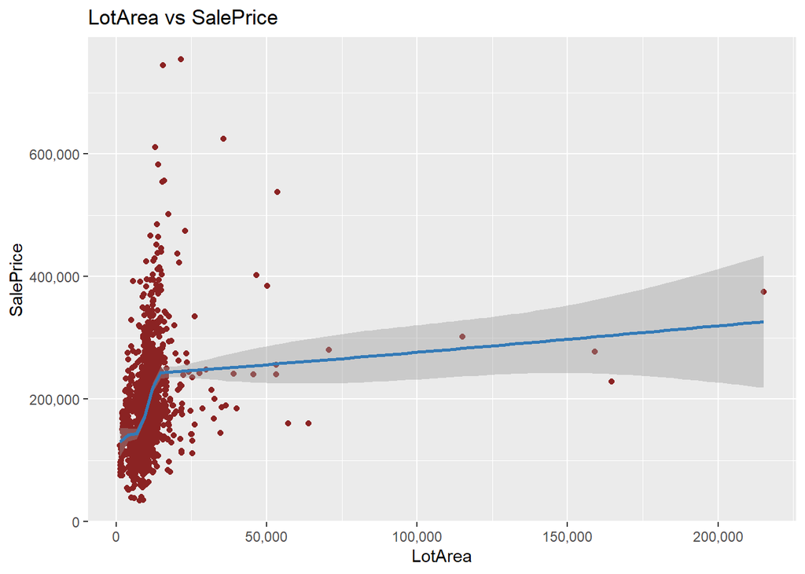

```r
trn_numeric %>% ggplot(aes(LotArea, SalePrice)) + geom_point(color = "brown4") + geom_smooth(method = "auto",
    col = "#337ab7") + ggtitle("LotArea vs SalePrice") +
    xlab("LotArea") + ylab("SalePrice") + scale_x_continuous(labels = comma) + scale_y_continuous(labels = comma)
```

##### Removing outliers (LotArea > 50, 000) and re-ploting below:

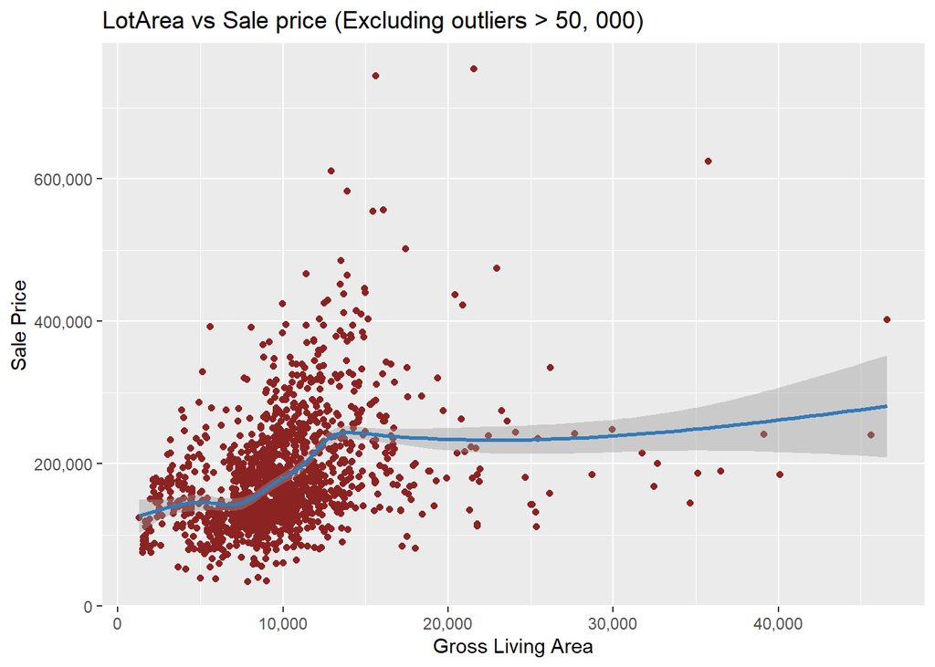

```r
trn_numeric %>% filter(LotArea < 50000) %>% ggplot(aes(LotArea, SalePrice)) + geom_point(color = "brown4") + geom_smooth(method = "auto",
    col = "#337ab7") + ggtitle("LotArea vs Sale price (Excluding outliers > 50, 000)") +
    xlab("Gross Living Area") + ylab("Sale Price") + scale_x_continuous(labels = comma) + scale_y_continuous(labels = comma)
```

###### TotalBsmtSF vs SalePrice

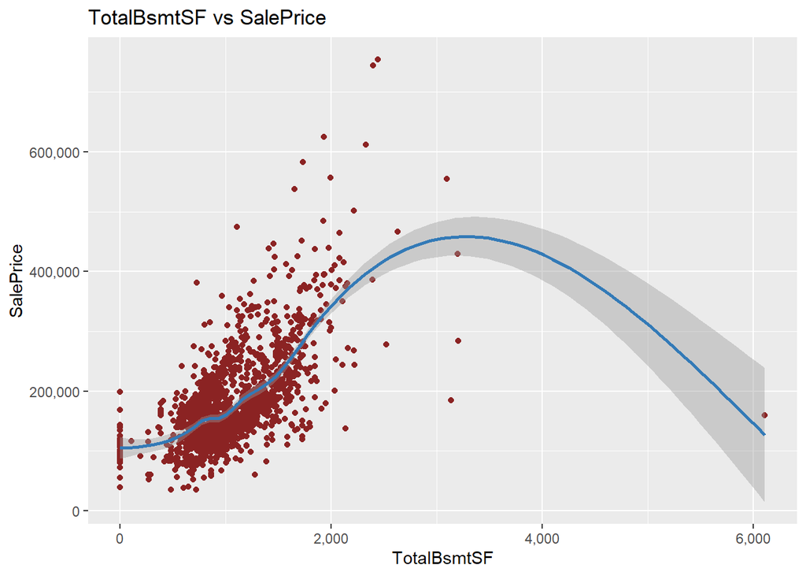

```r
trn_numeric %>% ggplot(aes(TotalBsmtSF, SalePrice)) + geom_point(color = "brown4") + geom_smooth(method = "auto",
    col = "#337ab7") + ggtitle("TotalBsmtSF vs SalePrice") +
    xlab("TotalBsmtSF") + ylab("SalePrice") + scale_x_continuous(labels = comma) + scale_y_continuous(labels = comma)
```

##### Removing outliers (TotalBsmtSF >= 4, 000) and re-ploting below:

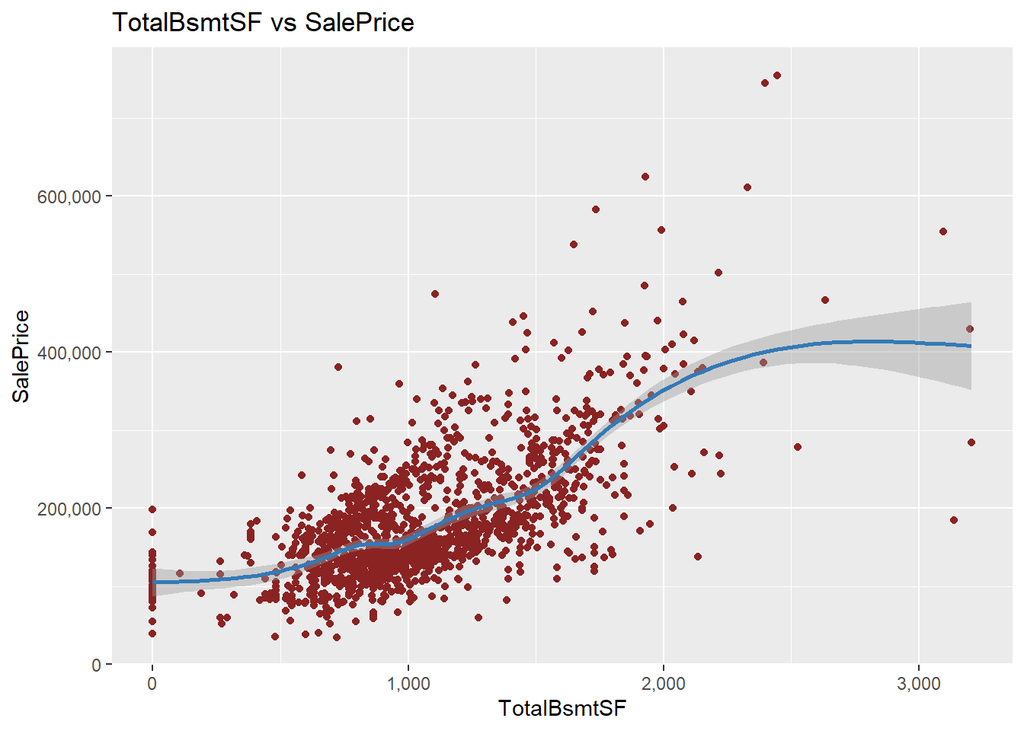

```r
trn_numeric %>% filter(TotalBsmtSF < 4000)%>% ggplot(aes(TotalBsmtSF, SalePrice)) + geom_point(color = "brown4") + geom_smooth(method = "auto",
    col = "#337ab7") + ggtitle("TotalBsmtSF vs SalePrice") +
    xlab("TotalBsmtSF") + ylab("SalePrice") + scale_x_continuous(labels = comma) + scale_y_continuous(labels = comma)
```

##### This shows there is a also a positive relationship between ‘TotalBsmtSF’ and ‘SalePrice’

##### From the above plots, having considered the relationships betwee GrLivArea and SalePrice, and between TotalBsmtSF and SalePrice, I will also investigate the nature of corelation between these variables with SalePrice and with one another.

```r
pd <- trn_numeric[c("SalePrice", "TotalBsmtSF", "GrLivArea")]
```

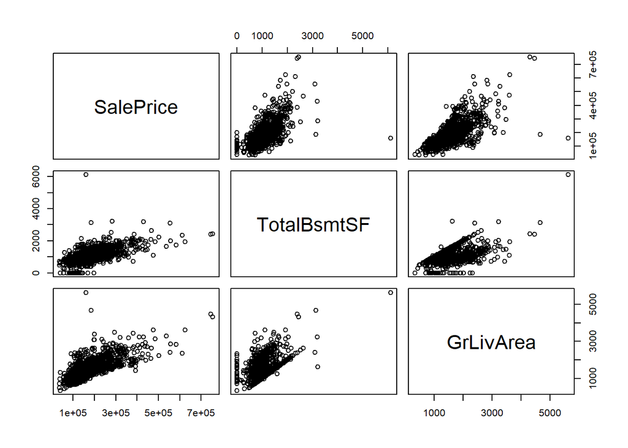

```r
pairs(pd)
```

```r
cor_matrix <- cor(pd)
```

```r
kable(cor_matrix, table.attr = "style = \"color: #000;\"") %>% kable_styling(bootstrap_options = c("bordered", 'striped', full_width = T))
```

|  | SalePrice | TotalBsmtSF | GrLivArea |
| --- | --- | --- | --- |
| SalePrice | 1.0000000 | 0.6135806 | 0.7086245 |
| TotalBsmtSF | 0.6135806 | 1.0000000 | 0.4548682 |
| GrLivArea | 0.7086245 | 0.4548682 | 1.0000000 |

##### The table of Co-relation matrix above suggests a strong corelation between ‘Saleprice’ and ‘TotalBsmtSF’ with a corelation coefficient of 0.61, as well as between ‘SalePrice’ and ‘GrLivArea’ with corelation coefficient 0.708. But the corelation between ‘TotalBsmtSF’ and ‘GrLivArea’ is not that strong as the corelation coefficientis 0.45

Visualising

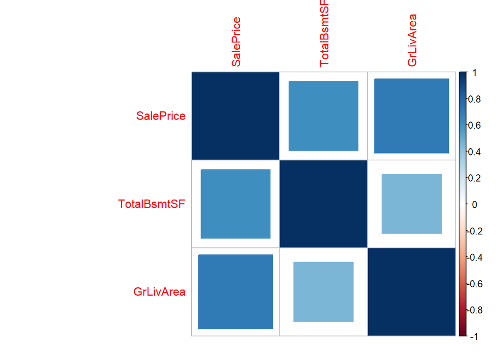

```r
corrplot(cor_matrix, method = "square")
```

##### Test the hypotheses that the correlations between each pairwise set of variables is 0 and provide an 80% confidence interval.

###### Testing between ‘TotalBsmtSF’ and ‘SalePrice’

```r
cor.test(trainData$TotalBsmtSF, trainData$SalePrice, method = "pearson", conf.level = 0.8)
```

```
##
##  Pearson's product-moment correlation
##
## data:  trainData$TotalBsmtSF and trainData$SalePrice
## t = 29.671, df = 1458, p-value < 2.2e-16
## alternative hypothesis: true correlation is not equal to 0
## 80 percent confidence interval:
##  0.5922142 0.6340846
## sample estimates:
##       cor
## 0.6135806
```

###### Testing between ‘GrLivArea’ and ‘SalePrice’

```r
cor.test(trainData$GrLivArea, trainData$SalePrice, method = "pearson", conf.level = 0.8)
```

```
##
##  Pearson's product-moment correlation
##
## data:  trainData$GrLivArea and trainData$SalePrice
## t = 38.348, df = 1458, p-value < 2.2e-16
## alternative hypothesis: true correlation is not equal to 0
## 80 percent confidence interval:
##  0.6915087 0.7249450
## sample estimates:
##       cor
## 0.7086245
```

##### Would you be worried about familywise error? Why or why not?

###### The family-wise error is the probability of commiting a type I error that is, rejecting a true null or accepting a false positive. As seen from the analysis above, the P value in each case is extremely small. So I would not be worried about committing type I error.

### Linear Algebra and Correlation: Invert your correlation matrix from above. (This is known as the precision matrix and contains variance inflation factors on the diagonal.) Multiply the correlation matrix by the precision matrix, and then multiply the precision matrix by the correlation matrix. Conduct LU decomposition on the matrix.

```r
percision_matrix <- solve(cor_matrix)
percision_matrix
```

```
##              SalePrice TotalBsmtSF   GrLivArea
## SalePrice    2.5582310 -0.93946422 -1.38549273
## TotalBsmtSF -0.9394642  1.60588442 -0.06473842
## GrLivArea   -1.3854927 -0.06473842  2.01124151
```

```r
cor_matrix %*% percision_matrix
```

```
##             SalePrice  TotalBsmtSF    GrLivArea
## SalePrice           1 1.387779e-17 0.000000e+00
## TotalBsmtSF         0 1.000000e+00 1.110223e-16
## GrLivArea           0 5.551115e-17 1.000000e+00
```

```r
percision_matrix%*%cor_matrix
```

```
##                SalePrice TotalBsmtSF    GrLivArea
## SalePrice   1.000000e+00           0 0.000000e+00
## TotalBsmtSF 2.775558e-17           1 6.938894e-17
## GrLivArea   0.000000e+00           0 1.000000e+00
```

```r
library(matrixcalc)
```

```r
(lu_D <- lu.decomposition(cor_matrix))
```

```
## $L
##           [,1]       [,2] [,3]
## [1,] 1.0000000 0.00000000    0
## [2,] 0.6135806 1.00000000    0
## [3,] 0.7086245 0.03218829    1
##
## $U
##      [,1]      [,2]      [,3]
## [1,]    1 0.6135806 0.7086245
## [2,]    0 0.6235189 0.0200700
## [3,]    0 0.0000000 0.4972053
```

```r
cor_matrix
```

```
##             SalePrice TotalBsmtSF GrLivArea
## SalePrice   1.0000000   0.6135806 0.7086245
## TotalBsmtSF 0.6135806   1.0000000 0.4548682
## GrLivArea   0.7086245   0.4548682 1.0000000
```

##### The LU decomposition yielded the correlation matrix after multiplying the percision matrix and correlation matrix as shown above.

### Calculus-Based Probability & Statistics:

#### Many times, it makes sense to fit a closed form distribution to data. Select a variable in the Kaggle.com training dataset that is skewed to the right, shift it so that the minimum value is absolutely above zero if necessary.

##### Using the original dataframe

```r
msVnA <- na.omit(trainData$MasVnrArea)
```

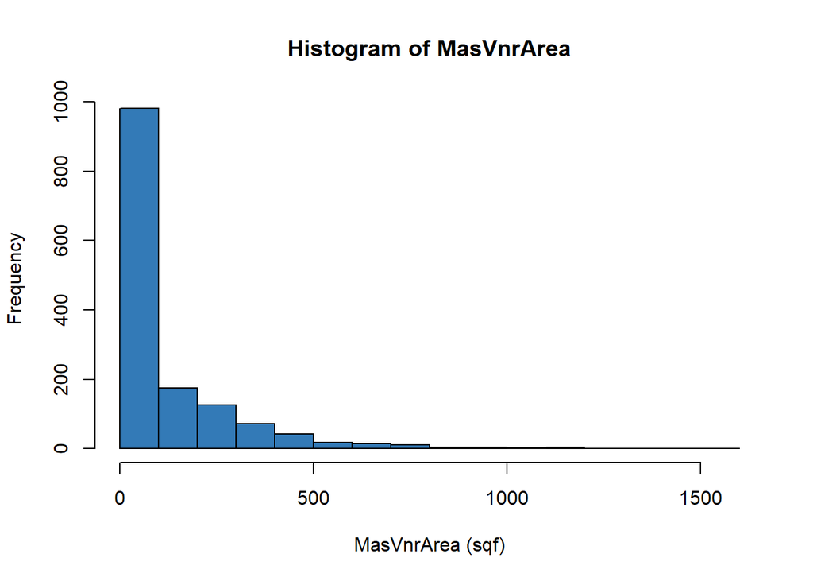

```r
hist(msVnA, breaks=15, main = "Histogram of MasVnrArea", xlab = 'MasVnrArea (sqf)', ylab = 'Frequency', col= '#337ab7')
```

##### MasVnrArea is really right-skewed

##### Calling the min() function on ‘MasVnrArea’

```r
min(msVnA)
```

```
## [1] 0
```

```r
msVnA <- msVnA + 10

summary(msVnA)
```

```
##    Min. 1st Qu.  Median    Mean 3rd Qu.    Max.
##    10.0    10.0    10.0   113.7   176.0  1610.0
```

##### This shows that MasVnrArea need to be shifted since its minimum value is 0.

#### Then load the MASS package and run fitdistr to fit an exponential probability density function. (See https://stat.ethz.ch/R-manual/R-devel/library/MASS/html/fitdistr.html ). Find the optimal value of $\lambda$ for this distribution, and then take 1000 samples from this exponential distribution using this value (e.g., rexp(1000, $\lambda$)).

```r
expoFit <- fitdistr(msVnA, densfun = "exponential")
```

```r
print(expoFit$estimate)
```

```
##        rate
## 0.008796215
```

```r
ss <- rexp(1000, expoFit$estimate)
sdf <- data.frame(ss)
```

#### Plot a histogram and compare it with a histogram of your original variable.

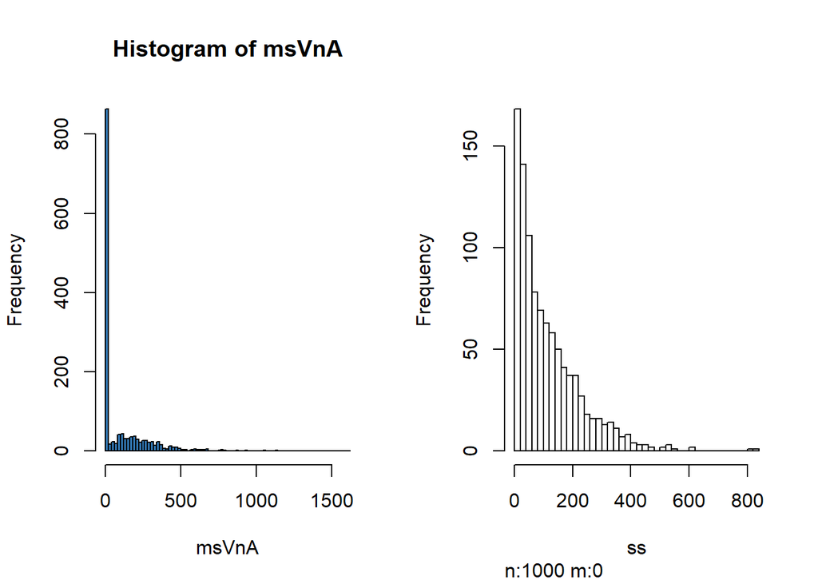

```r
par(mfrow=c(1, 2))
hist(msVnA, breaks = 100, col= '#337ab7')
hist(sdf, breaks = 100, col= '#337ab7')
```

#### Using the exponential pdf, find the 5th and 95th percentiles using the cumulative distribution function (CDF). Also generate a 95% confidence interval from the empirical data, assuming normality. Finally, provide the empirical 5th percentile and 95th percentile of the data. Discuss.

```r
dx <- dexp(ss, rate = expoFit$estimate)
```

```r
dt <- data.frame(ss, dx = dx)
```

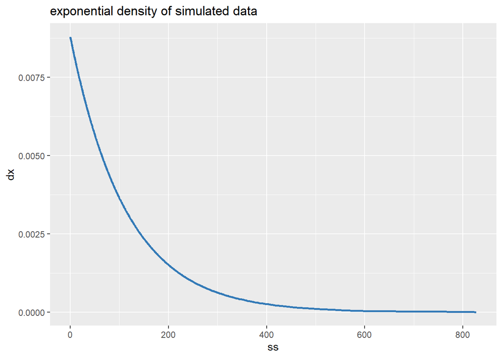

```r
ggplot(dt, aes(x = ss, y = dx)) + geom_line(lwd = 1, col = "#337ab7") + ggtitle("exponential density of simulated data")
```

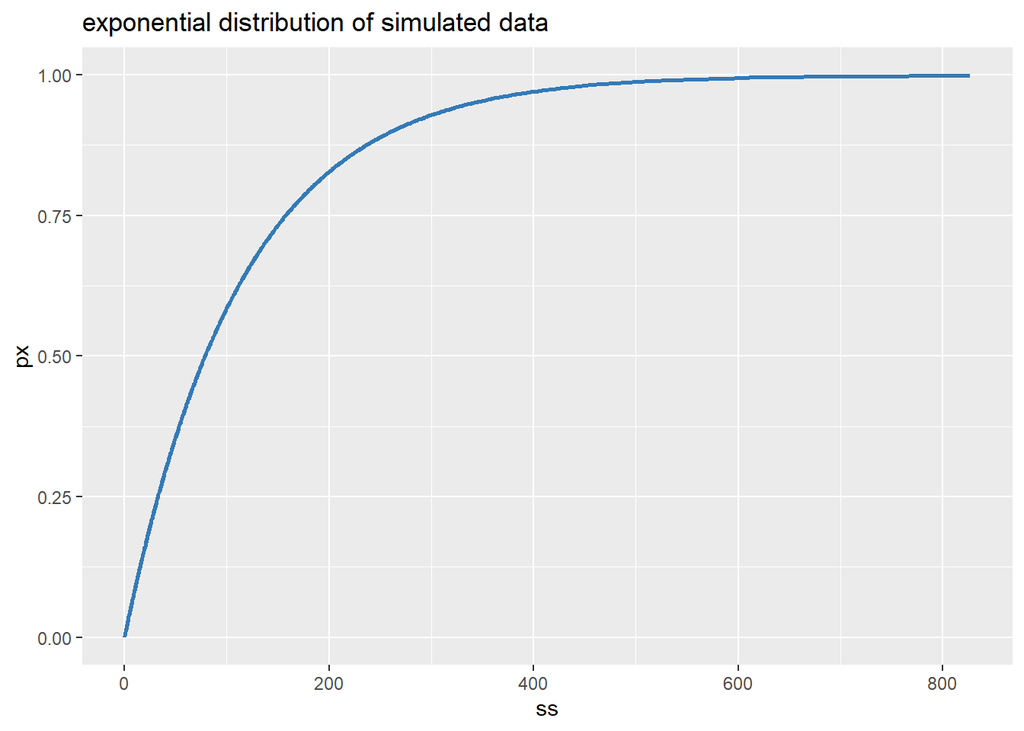

```r
dt2 <- data.frame(ss, px = pexp(ss, rate = expoFit$estimate))
ggplot(dt2, aes(x = ss, y = px)) + geom_line(lwd = 1, col = "#337ab7") + ggtitle("exponential distribution of simulated data")
```

##### 5th and 95th percentiles

```r
lmd <- as.numeric(expoFit$estimate)
(cdf_5 <-  round((-1/lmd)*(log(.95)),2))
```

```
## [1] 5.83
```

```r
(cdf_95 <-  round(-1/lmd*(log(.05)),2))
```

```
## [1] 340.57
```

##### The 5th and 95th percentiles are 5.83 and 340.57 respectively

```r
mn_va <- mean(msVnA)
sd_va <- sd(msVnA)
n_items <- length(msVnA)
```

```r
(err <- qnorm(0.975)*sd_va/sqrt(n_items))
```

```
## [1] 9.31327
```

```r
(lf <- mn_va - err)
```

```
## [1] 104.372
```

```r
(rt <- mn_va + err)
```

```
## [1] 122.9985
```

##### From the above, the 95% confidence interval falls between 104.372 and 122.998

##### Empirical 5th percentile and 95th percentile of the data:

```r
quantile(msVnA, probs=c(.05, .95))
```

```
##  5% 95%
##  10 466
```

```r
u <- msVnA[msVnA<100]

v <- msVnA[msVnA>125]

(length(u)+length(v))/length(msVnA)
```

```
## [1] 0.9641873
```

### Modeling:

#### Build some type of multiple regression model and submit your model to the competition board. Provide your complete model summary and results with analysis. Report your Kaggle.com user name and score.

##### I will select some of the variables from the original train data which I think have best relationships with SalePrice:.

```r
ft <- lm(trn_numeric$SalePrice ~ trn_numeric$OverallQual + trn_numeric$GrLivArea + trn_numeric$GarageCars + trn_numeric$LotArea + trn_numeric$MasVnrArea + trn_numeric$GarageArea, data=trn_numeric)
summary(ft)
```

```
##
## Call:
## lm(formula = trn_numeric$SalePrice ~ trn_numeric$OverallQual +
##     trn_numeric$GrLivArea + trn_numeric$GarageCars + trn_numeric$LotArea +
##     trn_numeric$MasVnrArea + trn_numeric$GarageArea, data = trn_numeric)
##
## Residuals:
##     Min      1Q  Median      3Q     Max
## -403271  -20532   -1216   17924  310318
##
## Coefficients:
##                           Estimate Std. Error t value Pr(>|t|)
## (Intercept)             -9.238e+04  4.930e+03 -18.738  < 2e-16 ***
## trn_numeric$OverallQual  2.641e+04  1.055e+03  25.029  < 2e-16 ***
## trn_numeric$GrLivArea    4.279e+01  2.580e+00  16.582  < 2e-16 ***
## trn_numeric$GarageCars   1.154e+04  3.027e+03   3.812 0.000143 ***
## trn_numeric$LotArea      7.942e-01  1.072e-01   7.406 2.19e-13 ***
## trn_numeric$MasVnrArea   4.237e+01  6.426e+00   6.593 6.01e-11 ***
## trn_numeric$GarageArea   3.004e+01  1.035e+01   2.903 0.003750 **
## ---
## Signif. codes:  0 '***' 0.001 '**' 0.01 '*' 0.05 '.' 0.1 ' ' 1
##
## Residual standard error: 39100 on 1445 degrees of freedom
##   (8 observations deleted due to missingness)
## Multiple R-squared:  0.7578, Adjusted R-squared:  0.7568
## F-statistic: 753.4 on 6 and 1445 DF,  p-value: < 2.2e-16
```

###### This shows that:

$SalePrice = 26407.9835*OverallQual + 42.7900*GrLivArea + 11539*GarageCars + 0.7942*LotArea + 42.3683*MasVnrArea + 30.0438*GarageArea - 92377.6833$

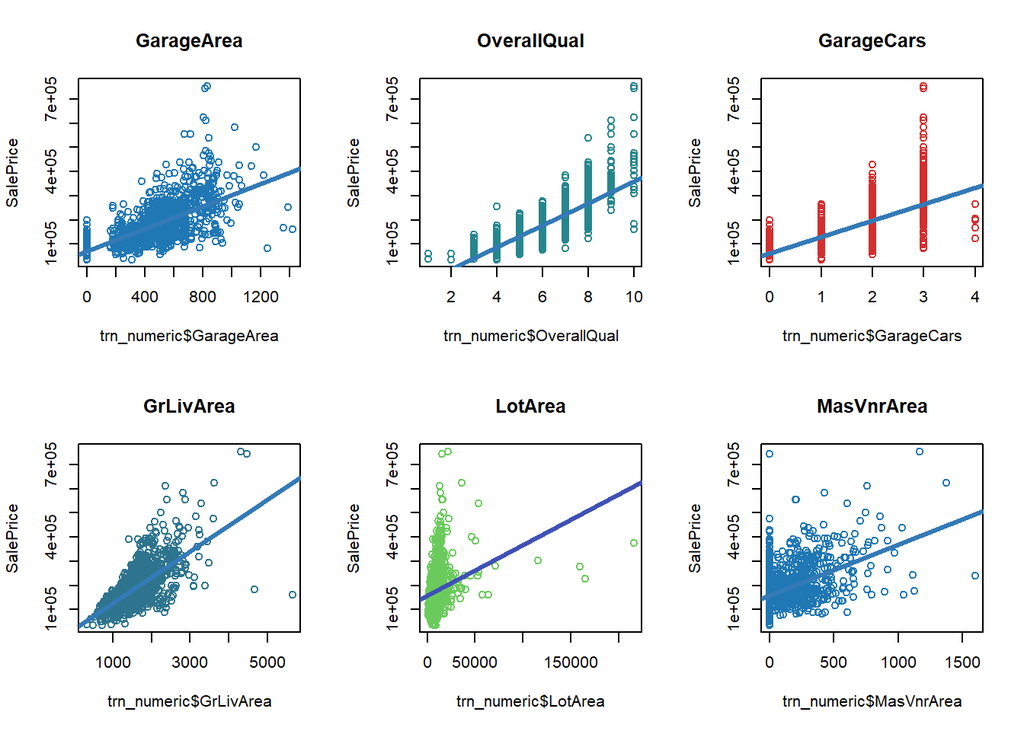

```r
par(mfrow=c(2,3))

plot(trn_numeric$GarageArea,trn_numeric$SalePrice, col="#1f77b4", main="GarageArea", ylab="SalePrice")
abline(lm(trn_numeric$SalePrice~trn_numeric$GarageArea), col="#337ab7", lwd=3)

plot(trn_numeric$OverallQual,trn_numeric$SalePrice, col="#26868d", main="OverallQual", ylab="SalePrice")
abline(lm(trn_numeric$SalePrice~trn_numeric$OverallQual), col="#337ab7", lwd=3)

plot(trn_numeric$GarageCars,trn_numeric$SalePrice, col="#D32F2F", main="GarageCars", ylab="SalePrice")
abline(lm(trn_numeric$SalePrice~trn_numeric$GarageCars), col="#337ab7", lwd=3)

plot(trn_numeric$GrLivArea,trn_numeric$SalePrice, col="#2e748e", main="GrLivArea", ylab="SalePrice")
abline(lm(trn_numeric$SalePrice~trn_numeric$GrLivArea), col="#337ab7", lwd=3)

plot(trn_numeric$LotArea,trn_numeric$SalePrice, col="#6acb5c", main="LotArea", ylab="SalePrice")
abline(lm(trn_numeric$SalePrice~trn_numeric$LotArea), col="#3F51B5", lwd=3)

plot(trn_numeric$MasVnrArea,trn_numeric$SalePrice, col="#1f77b4", main="MasVnrArea", ylab="SalePrice")
abline(lm(trn_numeric$SalePrice~trn_numeric$MasVnrArea), col="#337ab7", lwd=3)
```

##### Calculating SalePrice using the formular for SalePrice above

```r
SalePrice <- ((26407.9835*testData$OverallQual) + (42.7900*testData$GrLivArea) + (11539*testData$GarageCars) + (0.7942*testData$LotArea) + (42.3683*testData$MasVnrArea) + (30.0438*testData$GarageArea)  - 92377.6833)
```

```r
test_df <-testData[,c("Id","OverallQual","GrLivArea","GarageCars","GarageArea", "LotArea", "MasVnrArea")]
```

```r
datatable(head(test_df), class = 'cell-border stripe', options = list(
  initComplete = JS(
    "function(settings, json) {",
    "$(this.api().table().header()).css({'background-color': '#337ab7', 'color': '#fff', 'text-align': 'center !important'});",
    "$(this.api().table().body()).css({'color': '#000', 'text-align': 'center !important'});",
    "}")
))
```

|  | Id | OverallQual | GrLivArea | GarageCars | GarageArea | LotArea | MasVnrArea |
| --- | --- | --- | --- | --- | --- | --- | --- |
| 1 | 1461 | 5 | 896 | 1 | 730 | 11622 | 0 |
| 2 | 1462 | 6 | 1329 | 1 | 312 | 14267 | 108 |
| 3 | 1463 | 5 | 1629 | 2 | 482 | 13830 | 0 |
| 4 | 1464 | 6 | 1604 | 2 | 470 | 9978 | 20 |
| 5 | 1465 | 8 | 1280 | 2 | 506 | 5005 | 0 |
| 6 | 1466 | 6 | 1655 | 2 | 440 | 10000 | 0 |

```r
ff <- cbind(test_df$Id,SalePrice)
ff[ff < 0] <- median(SalePrice)
ff<- data.frame(ff[1:1459,])
ff[is.na(ff)] <- 0
colnames(ff)[1] <- "Id"
```

```r
datatable(head(ff), class = 'cell-border stripe', options = list(
  initComplete = JS(
    "function(settings, json) {",
    "$(this.api().table().header()).css({'background-color': '#337ab7', 'color': '#fff', 'text-align': 'center !important'});",
    "$(this.api().table().body()).css({'color': '#000', 'text-align': 'center !important'});",
    "}")
))
```

|  | Id | SalePrice |
| --- | --- | --- |
| 1 | 1461 | 120703.2406 |
| 2 | 1462 | 159757.4211 |
| 3 | 1463 | 157910.0418 |
| 4 | 1464 | 180675.8573 |
| 5 | 1465 | 215912.5185 |
| 6 | 1466 | 181126.9397 |

```r
write.csv(ff, file = 'final_output.csv', quote=FALSE, row.names=FALSE)
```

##### First, I chose to go with those variables that has high level of correlation with SalePrice. This decision was informed by the results of the corelation plots above. I have understood from past courses that using a lot of variables in modelling might affect model fitting (either over fitting or under fitting), but using fewer variables does not guaranty excellent result. Therefore proper investigations like using the corelation plots can come in handy when choosing variables. Also, adding or removing the variables while evaluating the statistical significance at each point. I used four of the variables (OverallQual,GrLivArea,GarageCars, GarageArea) and got a 0.78436 score on kaggle. I thought I could improve this so I added , LotArea and MasVnrArea variables to the model. I was told my submission was 1.20957 but that it is not improvement to the original score. I can’t really say what that means but I can say that the six scatter plots show linear and normal distribution.

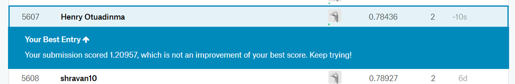

```r
knitr::include_graphics('https://raw.githubusercontent.com/henryvalentine/MSDS2019/master/Classes/605/Final%20Project/kaggle_2.png')
```